# 意大利新冠肺炎疫情预测及理性评估

戎翔 高彦梅 卫晓帆 李宇

# 数据分析

## 数据来源

本次报告是基于意大利新冠肺炎的情况来预测它未来的发展情况，因此我们收集了意大利2020年3月1日到2020年3月30日的疫情数据展开分析，这些数据来源于世界卫生组织公布的每日疫情数据，以及意大利卫生部公布的每日疫情数据，其中累计治愈人数是截至每天的下午六点。

## 数据分析

1、我们首先对意大利3月份新冠肺炎累计确诊情况进行分析，其累计确诊病例趋势如下图所示：

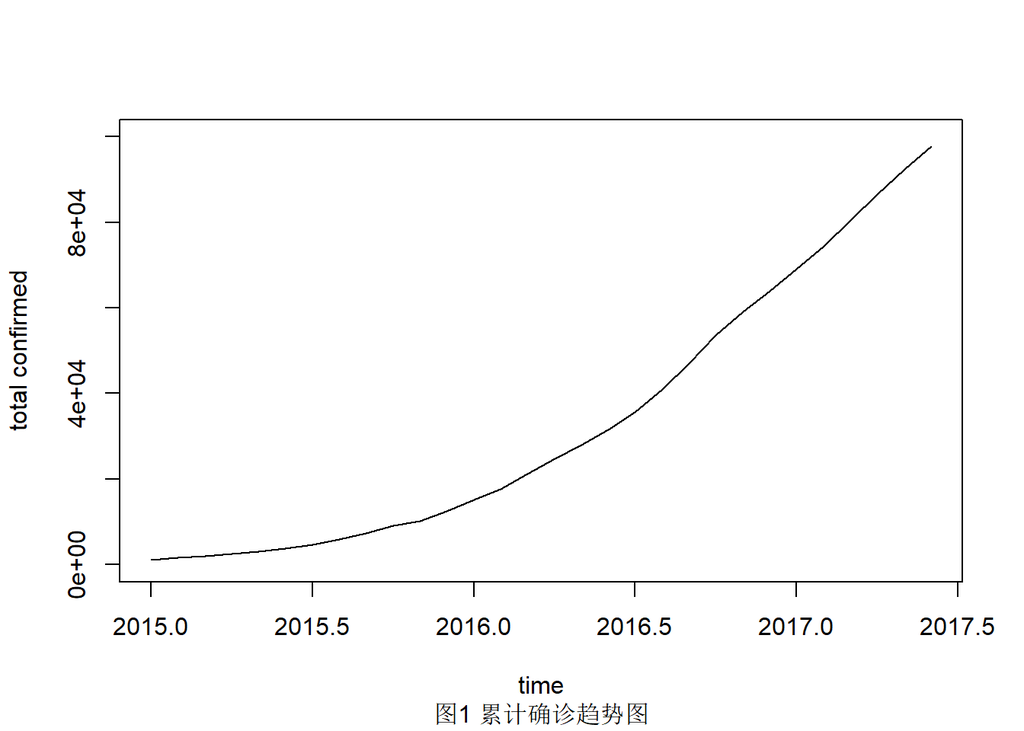

从上图可以看出，自3月份以来，意大利新冠肺炎的累计确诊情况几乎呈指数形式增长，从最初的一天增加几百个，到后来，一天增加几千个。但我们也发现，随着时间的推移，大约从3月20日开始，每日新增的患者大概在5000左右波动，近乎呈线性趋势。因此，我们在后期的预测过程中，可以进行分时间段来拟合累计确诊曲线，进而对意大利新冠肺炎疫情做出预测。

2、通过刻画意大利新冠肺炎的累计确诊情况，我们进一步分析意大利新冠肺炎每日新增情况机器增长率。结果如图所示：

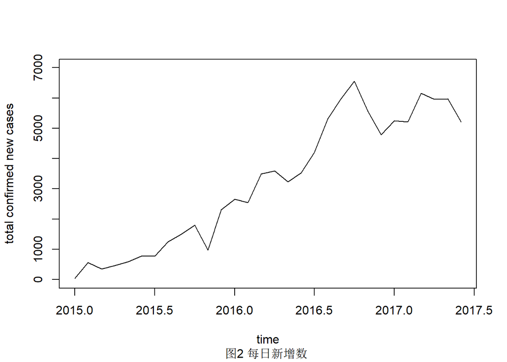

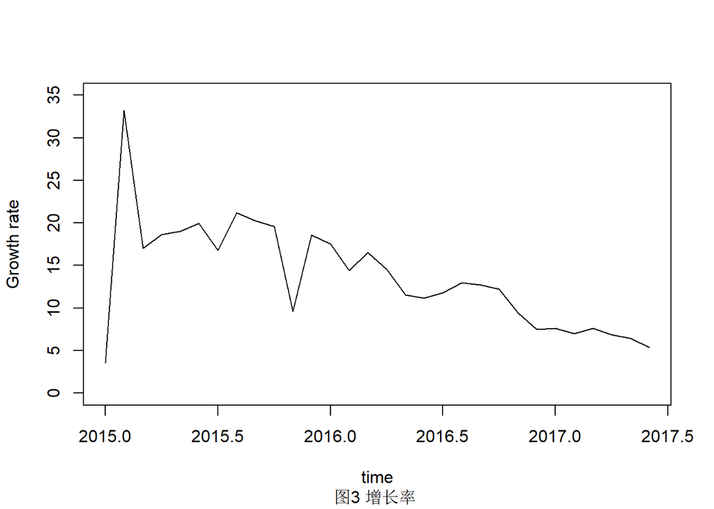

观察上图，我们发现，在3月22日，新增确诊人数达到最大，其最大值为6557，在这之前，新增确诊人数在波动中逐渐上升，在22日之后，新增确诊人数处于上下波动中，其变化趋势具有不确定性。但我们发现其增长率曲线则大致呈下降趋势，由最初的33.21%到3月30日的5.34%，这可能与意大利累计确诊人数这一变量的基数不断增大有关，但是，我们相信在世界各国的共同努力下，以及意大利政府的干预下，增长率为0的日子将很快到来。

3、下面我们将进一步分析意大利的治愈情况，结果如图所示：

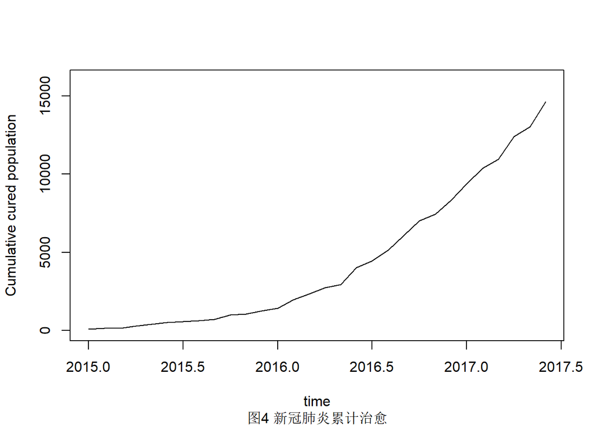

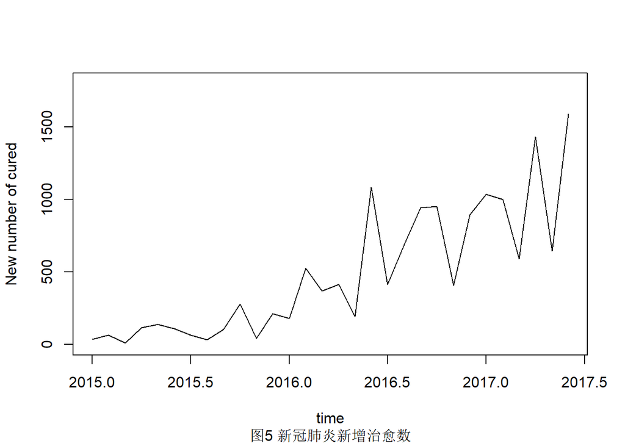

从上图发现，意大利新冠肺炎累计治愈趋势图与累计确诊趋势图具有相同的增长趋势，都近乎呈指数增长，但在后期，几乎呈线性趋势。每日新增治愈人数则呈现出一定的周期性，并且具有波动性，在波动中上升。

累计确诊情况与累计治愈情况的相似性,可以用同样的方法进行预测。

4、为进一步了解意大利新冠肺炎造成的死亡情况，我们刻画了在这段时间的死亡率变化图，如下图所示：

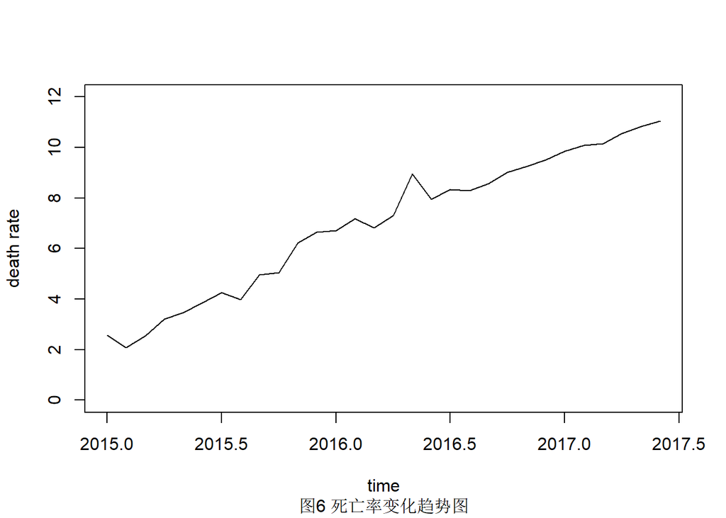

意大利新冠肺炎的死亡率逐渐递增，尽管在这个过程中有一定的波动，但整体上看它呈现出线性趋势，这也从侧面反映了其医疗条件有待提高，政府应增加医院数目，增加救治率，减少死亡人数。

（情况说明，将数据格式设置为时间序列的格式时，没有找到怎么将数据的频率设置为天，目前先设置为月度数据。）